# Chemical Structures of PCBs congeners

6.6

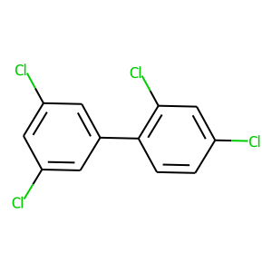

2,3',4,6-Tetrachlorobiphenyl

60233-24-1

C12H6Cl4

6.3

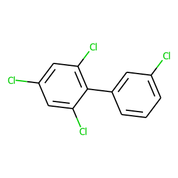

2,3',4',5-Tetrachlorobiphenyl

32598-11-1

C12H6Cl4

6.2

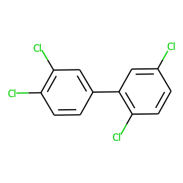

2,3',4',6-Tetrachlorobiphenyl

41464-46-4

C12H6Cl4

6.5

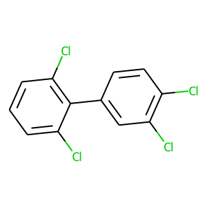

2,3',5,5'-Tetrachlorobiphenyl

41464-42-0

C12H6Cl4

6.4

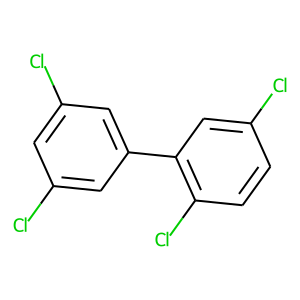

2,3',5',6-Tetrachlorobiphenyl

74338-23-1

C12H6Cl4

6.1

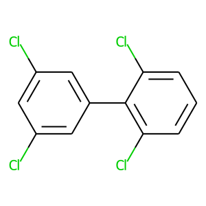

2,4,4',5-Tetrachlorobiphenyl

32690-93-0

C12H6Cl4

6.7

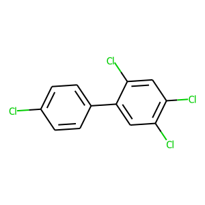

2,4,4',6-Tetrachlorobiphenyl

32598-12-2

C12H6Cl4

6.3

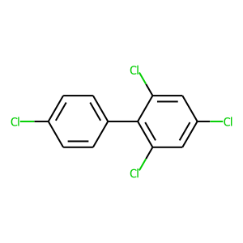

2,3',4',5'-Tetrachlorobiphenyl

70362-48-0

C12H6Cl4

6.5

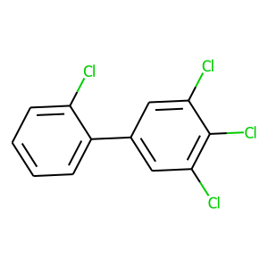

3,3',4,4'-Tetrachlorobiphenyl

32598-13-3

C12H6Cl4

6.6

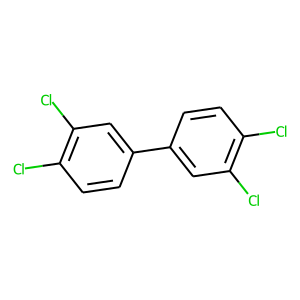

3,3',4,5-Tetrachlorobiphenyl

70362-49-1

C12H6Cl4

6.1

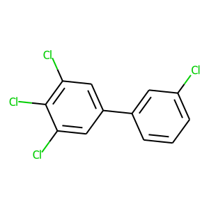

3,3',4,5'-Tetrachlorobiphenyl

41464-48-6

C12H6Cl4

6.5

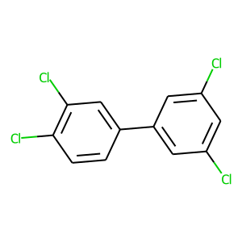

3,3',5,5'-Tetrachlorobiphenyl

33284-52-5

C12H6Cl4